# Project Python Foundations: FoodHub Data Analysis

# Relationship between Cuisine Type / Rating

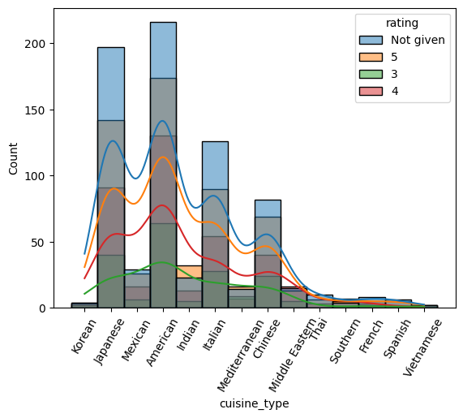

```python
plt.xticks(rotation=60)
sns.histplot(data=df, x='cuisine_type', hue ='rating', kde=True);
```

### Observations:

Maximum number of Rating data as well as ratings seems to be available for american, japanese, Italian cuisines

# Relationship between Food_preparation_time / day_of_the_week

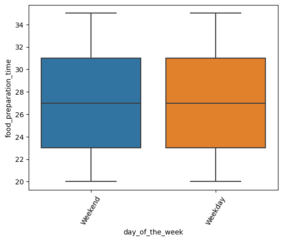

```python
plt.xticks(rotation=60)
sns.boxplot(data = df, y = "food_preparation_time", x = "day_of_the_week");
```

### Observations:

food-prep-time is same on weekdays and weekends

# Relationship between food_preparation_time / rating

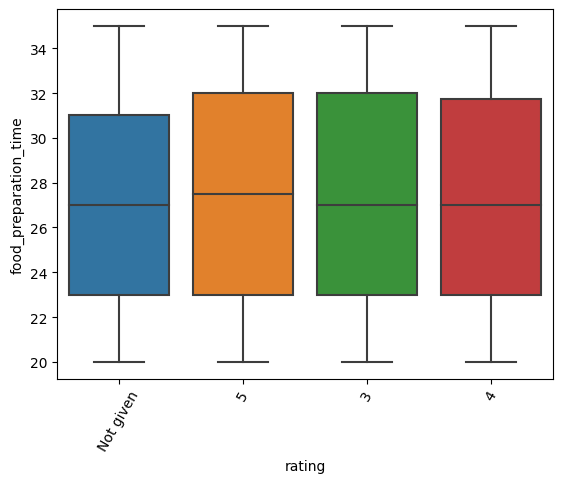

```python
plt.xticks(rotation=60)
sns.boxplot(data = df, y = "food_preparation_time", x = "rating");
```

### Observations:

Food preparation time has no impact on ratings

# Relationship between delivery_time / day_of_the_week

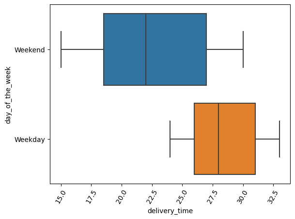

```python
plt.xticks(rotation=60)
sns.boxplot(data = df, x = "delivery_time",y = "day_of_the_week");
```

### Observation:

# Relationship between delivery_time / rating

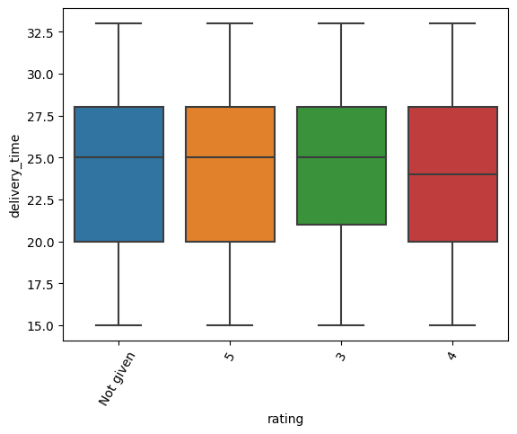

```python
plt.xticks(rotation=60)
sns.boxplot(data = df, y = "delivery_time", x = "rating");
```

### Observations:

Food prep time and delivery time has no impact on ratings

# Relationship between Total Time (food_prep_time+delivery_time) / rating

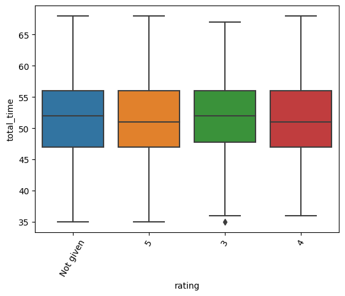

```python
df['total_time']= df['food_preparation_time']+ df['delivery_time']
plt.xticks(rotation=60)
sns.boxplot(data = df, y = "total_time", x = "rating");
```

### Observations:

Food prep time and delivery time has no impact on ratings

# Relationship between total_time / day_of_the_week

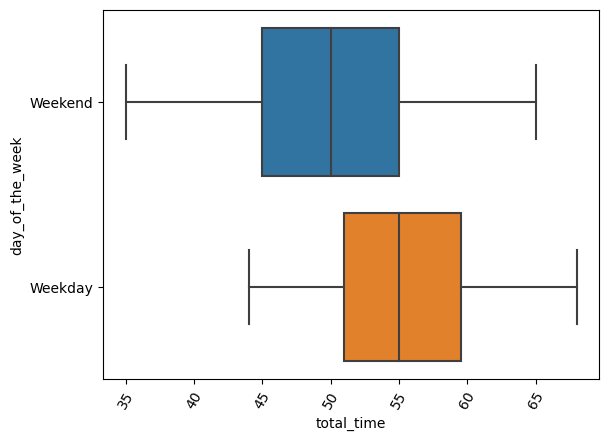

```python
plt.xticks(rotation=60)
sns.boxplot(data = df, x = "total_time", y = "day_of_the_week");
```

### Observations:

1. Total time (delivery + food-prep-time) for orders on weekends is 5 mins lesser than on weekdays.
2. 75% of orders on weekdays take 60mins, and on weekends 55mins.
3. Median time for orders on weekdays in 55 mins. Median time for orders on weekends on 50 mins.

# Relationship between binned_costs / rating

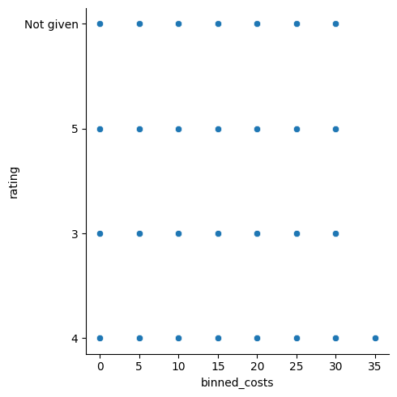

```python
# binned cost / cuisine
df['binned_costs']=pd.cut(df['cost_of_the_order'], bins = [0,5,10,15,20,25,30,35,40,45,50,55,60,65,70], labels=['0','5','10','15','20','25','30','35','40','45','50','55','60','65'])

sns.relplot(data = df, x = "binned_costs", y = "rating");
# binned cost /ratings
#pd.cut(data['cost_of_the_order'])
```

### Observation:

No difference in ratings across price-ranges